# Advanced Text Analysis

## SICSS-Munich, Day 4

Session 3️⃣: Vector Space Models

Valerie Hase (LMU Munich)

github.com/valeriehase

[valerie-hase.com](https://valerie-hase.com/)

## Agenda

- (Sparse) Vector Space Models (VSM)
- Their Limitations

## Going beyond bag-of-words

- Identifying meaning through ngrams (Session 2️⃣)
- Identifying meaning through syntax (Session 2️⃣)
- **Identifying meaning through semantic spaces** (Session 3️⃣, 4️⃣)

## Vector Space Models

- [Vector Space Models](https://en.wikipedia.org/wiki/Vector_space_model) (VSM): Represent documents/words as a vector in a vector space: Vectors that are closer together in space are semantically similar and vectors that are far apart are semantically distant. (Turney & Pantel, 2010)
- Idea very much pre-CSS
- Stems from information retrieval (Salton, 1971)
- We start with: **documents as vectors**

## Documents as Vectors

Basic idea (& some notation 🤓)

- Let $w$ be a word
- Let $D = (w_1, w_2, w_3, …, w_N)$ be a document consisting of sequences of words. For example, $D_1$: *“I like fruit like apple and kiwi”*.
- Let $V$ be the vocabulary, with size $|V|$ = $N$ (number of unique words)

## Documents as Vectors

- Idea 💡: We can represent each document $D$ via a frequency vector including all its words:
- Take example sentence $D_1$: *“I like fruit like apple and kiwi”*
- $D_1$ = (I, like, fruit, like, apple, and, kiwi)
- $V$ = (I, like, fruit, apple, and, kiwi), $|V|$ = 6

## Documents as Vectors

- Idea 💡: We can represent each document $D$ via a frequency vector described by its words which is located in an $N$-dimensional space:
- Take example sentence $D_1$: *“I like fruit like apple and kiwi”*
- Document represented as seven vectors $D_1 = (w_1, w_2, w_3, …, w_7)$, one for each $w_i$, of length $|V|$ = $N$ = 6 (our dimensions) including only 0/1 (*one-hot-encoding*):

$$V_{D_1} = \sum_{i=1}^{7} V_{wi} =\begin{pmatrix} 1 \\ 0 \\ 0 \\ 0 \\ 0 \\ 0 \end{pmatrix} + \begin{pmatrix} 0 \\ 1 \\ 0 \\ 0 \\ 0 \\ 0\end{pmatrix} + \begin{pmatrix} 0 \\ 0 \\ 1 \\ 0 \\ 0 \\ 0\end{pmatrix} + \begin{pmatrix} 0 \\ 1
\\ 0 \\ 0 \\ 0 \\ 0\end{pmatrix} + \begin{pmatrix} 0 \\ 0 \\ 0 \\ 1 \\ 0\\ 0\end{pmatrix} + \begin{pmatrix} 0 \\ 0 \\ 0 \\ 0 \\ 1\\ 0\end{pmatrix} + \begin{pmatrix} 0 \\ 0 \\ 0 \\ 0 \\ 0 \\ 1\end{pmatrix} = \begin{pmatrix} 1 \\ 2 \\ 1 \\ 1 \\ 1\\ 1\end{pmatrix}$$

## Documents as Vectors

- Idea 💡: We can represent each document $D$ via a frequency vector described by its words which is located in an $N$-dimensional space:
- Take example sentence $D_1$: *“I like fruit like apple and kiwi”*
- Document represented as seven vectors $D_1 = (w_1, w_2, w_3, …, w_7)$, one for each $w_i$, of length $|V|$ = $N$ = 6 (our dimensions) including only 0/1 (*one-hot-encoding*):
- Document then represend via a single word-frequency vector [1, 2, 1, 1, 1, 1]

## Documents as Vectors

- Using the vector representation, we can now represent the sentence *“I like fruit like apple and kiwi”* in a $N$-dimensional vector space.
- To create a 2-dimensional vector space, we only consider words *“kiwi”* as the $x$-axis and and *“like”* as the $y$-axis:

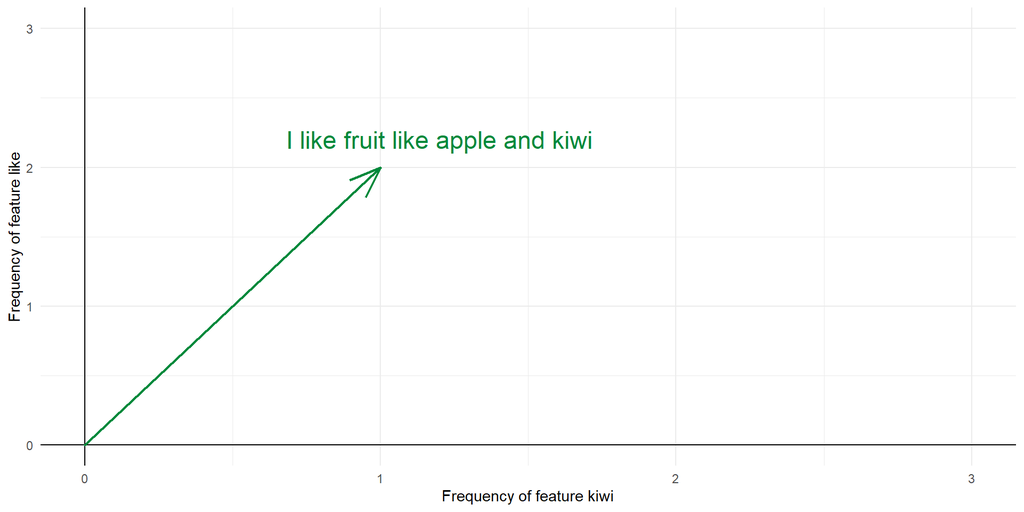

## Documents as Vectors

- Now, we let’s add two other sentences to see how they compare: *“I like kiwi, only kiwi”* (Sentence 2) and *“I only like vegetables, especially potato”* (Sentence 3).

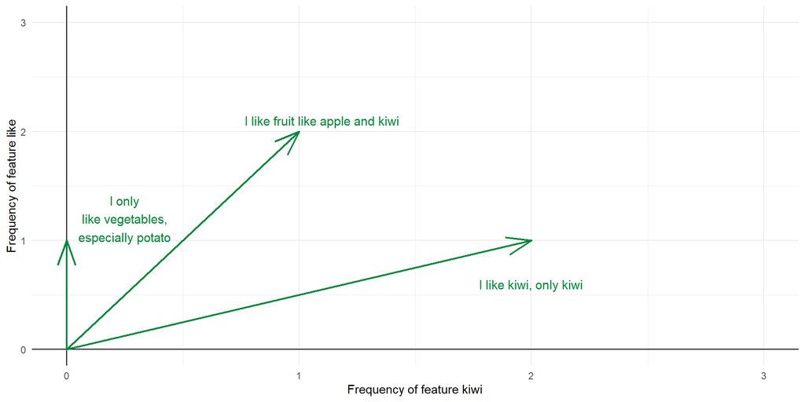

## Documents as Vectors

- We can now calculate the distance between these vectors
- Use distance/similarity metrics (e.g., Euclidean distance, cosine similarity, etc).

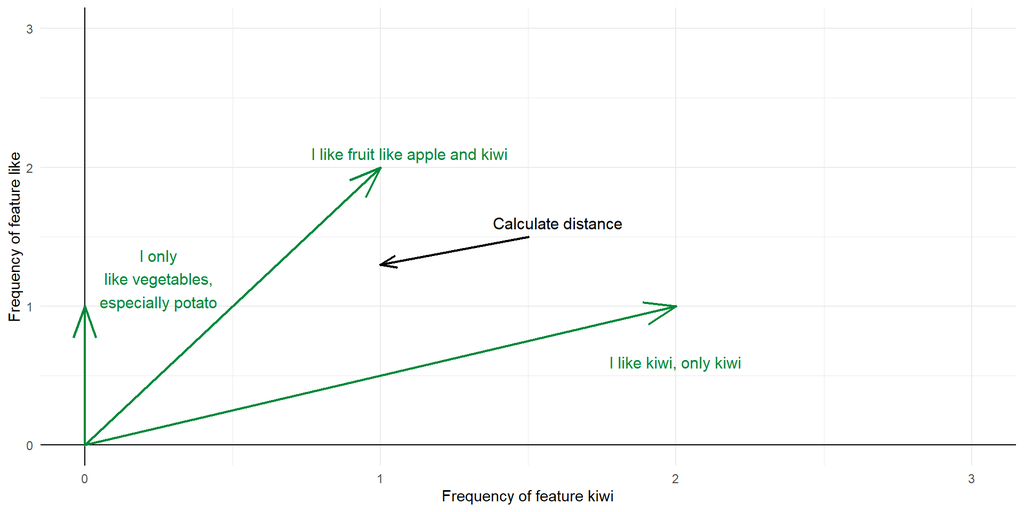

## Documents as Vectors in R

- In R, we can compute similarities between word vectors:
  - set-up vectors (e.g., sentence 1 as [1, 2] in 2-dimensional space)
  - compute similarity/distance, e.g. using `cosine` function from `lsa`
- However, packages like `textreuse` make this bit easier (and offer more/better methods)

```r
library("lsa")
sent_1 <- c(1, 2)
sent_2 <- c(2, 1)
sent_3 <- c(0, 1)
cosine(sent_1, sent_3)
```

```
          [,1]
[1,] 0.8944272
```

```r
cosine(sent_1, sent_2)
```

```
     [,1]
[1,]  0.8
```

**How could we use these methods for social science questions?** 🤔

## Identifying meaning through semantic spaces (sparse VSM): Overview 📚

- **Methods**: Documents as sparse vectors (for now) in $N$-dimensional space
- **Use for**: Text similarity, text-reuse, plagiarism detection, media bias
- **Examplary studies**:
  - for measuring media bias: Mozer et al. (2020)
- **Packages**:
  - [lsa](https://cran.r-project.org/web/packages/textreuse)
  - textreuse and related publication (Mullen, 2020)

## Word as Vectors

We already know that we can also represent word as vectors!

Remember the *one-hot-encoding* of the sentence *I like fruit like apple and kiwi*?

$$V_{D_1} = \sum_{i=1}^{7} V_{wi} =\begin{pmatrix} 1 \\ 0 \\ 0 \\ 0 \\ 0 \\ 0 \end{pmatrix} + \begin{pmatrix} 0 \\ 1 \\ 0 \\ 0 \\ 0 \\ 0\end{pmatrix} + \begin{pmatrix} 0 \\ 0 \\ 1 \\ 0 \\ 0 \\ 0\end{pmatrix} + \begin{pmatrix} 0 \\ 1
\\ 0 \\ 0 \\ 0 \\ 0\end{pmatrix} + \begin{pmatrix} 0 \\ 0 \\ 0 \\ 1 \\ 0\\ 0\end{pmatrix} + \begin{pmatrix} 0 \\ 0 \\ 0 \\ 0 \\ 1\\ 0\end{pmatrix} + \begin{pmatrix} 0 \\ 0 \\ 0 \\ 0 \\ 0 \\ 1\end{pmatrix} = \begin{pmatrix} 1 \\ 2 \\ 1 \\ 1 \\ 1\\ 1\end{pmatrix}$$

## Wait… is this not still bag-of-words?

Yes! 👀 - so old & new problems of (sparse) VSM include…

- ❌ Computationally inefficient (large , sparse vectors!)
- ❌ Semantic meaning of words not captured: similar words, different vectors

⏭️ Welcome to the world of distributed representations, especially: embeddings! (next up!)

**Any questions?** 🤔

## References

[figure not shown]

[Advanced Text Analysis - SICSS-Munich 2023 - Valerie Hase](https://github.com/valeriehase)

Mozer, R., Miratrix, L., Kaufman, A. R., & Jason Anastasopoulos, L. (2020). Matching with Text Data: An Experimental Evaluation of Methods for Matching Documents and of Measuring Match Quality. *Political Analysis*, *28*(4), 445–468. https://doi.org/10.1017/pan.2020.1

Mullen, L. (2020). *Textreuse: Detect text reuse and document similarity*.

Salton, G. (1971). *The SMART retrieval system - experiments in automatic document processing*. Prentice-Hall, Inc.

Turney, P. D., & Pantel, P. (2010). From Frequency to Meaning: Vector Space Models of Semantics. *Journal of Artificial Intelligence Research*, *37*, 141–188. https://doi.org/10.1613/jair.2934